# From Messy Data to Clean Maps

LaTreese Denson & Alex Davis

06/16/2021

## Workshop Objectives:

- Gain a working knowledge of data cleaning steps using the Tidyverse R.
- Perform computations and statistical analyses using various base functions and packages in R.
- Produce publishable content using the ggplot package in R.

**Note:** If you have quick questions about how to use these packages check out the cheat sheets:

[ggplot2 cheat sheet](https://www.rstudio.com/wp-content/uploads/2015/03/ggplot2-cheatsheet.pdf)

dplyr cheat sheet

… or **Google it**!

# Import Data

Read in the [growth_data](https://raw.githubusercontent.com/latreesedenson/SEAinCode/main/growth_data.csv) from Github using `read.csv()` and give it the object name “data” using `=` or `->` as the assignment operator:

```r
data = read.csv("https://raw.githubusercontent.com/latreesedenson/SEAinCode/main/growth_data.csv")

data = as.data.frame(data)
```

**Note:** You could also copy and paste the data from the web browser into an excel file, change the format to comma delimited, saved it as a csv file and then read it in using `read.csv()`. This way you would have a copy of the data on your local drive to read from. You would need to replace the weblink with the path to the data on your local computer.

# Clean Data

Make sure the data was read in correctly using the function `head()`. And look at parts of the data using the `$` operator.

```r
head(data)
```

```
##   daylength temp_range   growth species
## 1     short    average 132.9485       A
## 2   average    average 131.2542       A
## 3      long    average 125.8153       A
## 4     short      above 123.1229       A
## 5   average      above 106.3336       A
## 6      long      above 100.3005       A
```

```r
data$temp_range
```

```
##   [1] "average" "average" "average" "above"   "above"   "above"   "below"
##   [8] "below"   "below"   "average" "average" NA        "above"   "above"
##  [15] "above"   NA        "below"   "below"   "average" "average" "average"
##  [22] "above"   NA        "above"   "below"   "below"   "below"   "average"
##  [29] "average" "average" "above"   "above"   "above"   "below"   "below"
##  [36] "below"   "average" "average" "average" "above"   "above"   "above"
##  [43] "below"   "below"   "below"   "average" "average" "average" "above"
##  [50] "above"   "above"   "below"   "below"   "below"   "average" "average"
##  [57] "average" "above"   "above"   "above"   "below"   "below"   "below"
##  [64] "average" "average" "average" "above"   "above"   "above"   "below"
##  [71] "below"   "below"   "average" "average" "average" "above"   "above"
##  [78] "above"   "below"   "below"   "below"   "average" "average" "average"
##  [85] "above"   "above"   NA        "below"   "below"   "below"   "average"
##  [92] "average" "average" "above"   "above"   NA        "below"   "below"
##  [99] "below"   "average" "average" "average" "above"   "above"   "above"
```

[output cut: 24 more lines]

**ProTip:** Not sure what a function does? Type `?head()` into the console and see what pops up in the help menu. Scroll down to the bottom–there are often examples of how to use the function that you can practice with.

What are the column names? Is everything there that should be there?

```r
names(data)
```

```
## [1] "daylength"  "temp_range" "growth"     "species"
```

What are the dimensions of the dataset, how many rows and columns?

```r
dim(data)
```

```
## [1] 270   4
```

Let’s get some basic summary statistics from our data: minimums, maximums and means.

```r
summary(data)
```

```
##   daylength          temp_range            growth         species
##  Length:270         Length:270         Min.   : 64.41   Length:270
##  Class :character   Class :character   1st Qu.: 94.48   Class :character
##  Mode  :character   Mode  :character   Median :105.66   Mode  :character
##                                        Mean   :102.97
##                                        3rd Qu.:111.64
##                                        Max.   :143.50
```

You will notice that there were multiple species here and some NAs in the data. Let’s work with the first species and remove the bad records. We will use the pipe operator `%>%` from the magrittr package within the tidyverse to do this. This syntax leads to code that is easier to write and to read. Use the keyboard shortcut: Ctrl + Shift + M (Windows) or Cmd + Shift + M (Mac) to get the pipe operator.

```r
library(tidyverse)
Species_A_Clean = data %>% filter(species =="A",!is.na(temp_range))

head(Species_A_Clean)
```

```
##   daylength temp_range   growth species
## 1     short    average 132.9485       A
## 2   average    average 131.2542       A
## 3      long    average 125.8153       A
## 4     short      above 123.1229       A
## 5   average      above 106.3336       A
## 6      long      above 100.3005       A
```

```r
dim(Species_A_Clean)
```

```
## [1] 86  4
```

```r
summary(Species_A_Clean)
```

```
##   daylength          temp_range            growth         species
##  Length:86          Length:86          Min.   : 99.95   Length:86
##  Class :character   Class :character   1st Qu.:106.27   Class :character
##  Mode  :character   Mode  :character   Median :111.17   Mode  :character
##                                        Mean   :116.64
##                                        3rd Qu.:130.04
##                                        Max.   :143.50
```

Notice that there are no more NAs in the temp_range summary.

```r
Species_A_Clean$temp_range
```

```
##  [1] "average" "average" "average" "above"   "above"   "above"   "below"
##  [8] "below"   "below"   "average" "average" "above"   "above"   "above"
## [15] "below"   "below"   "average" "average" "average" "above"   "above"
## [22] "below"   "below"   "below"   "average" "average" "average" "above"
## [29] "above"   "above"   "below"   "below"   "below"   "average" "average"
## [36] "average" "above"   "above"   "above"   "below"   "below"   "below"
## [43] "average" "average" "average" "above"   "above"   "above"   "below"
## [50] "below"   "below"   "average" "average" "average" "above"   "above"
## [57] "above"   "below"   "below"   "below"   "average" "average" "average"
## [64] "above"   "above"   "above"   "below"   "below"   "below"   "average"
## [71] "average" "average" "above"   "above"   "above"   "below"   "below"
## [78] "below"   "average" "average" "average" "above"   "above"   "below"
## [85] "below"   "below"
```

# Basic Visualization and Analyses

Let’s do a boxplot of our response vs. our explanatory variables. Here we are using the ggplot2 package, but I also provide code for using Base R.

ggplot can get a bit complex depending on what you want to do but the basic components are typically the same.

You will notice that I have commented out some lines of code using ‘#’. This allows me to block out lines that I don’t want to run, as well as create comments for a better explanation of my code.

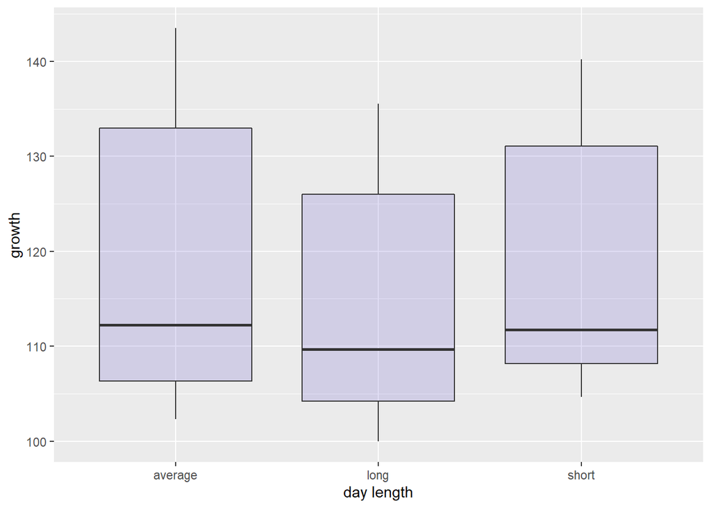

```r
# ggplot general inputs/arguments (data, aesthetics - x and y) + plot type + etc.

ggplot(Species_A_Clean, aes(x=as.factor(daylength), y=growth)) +
  geom_boxplot(fill="slateblue", alpha=0.2) +  xlab("day length")
```

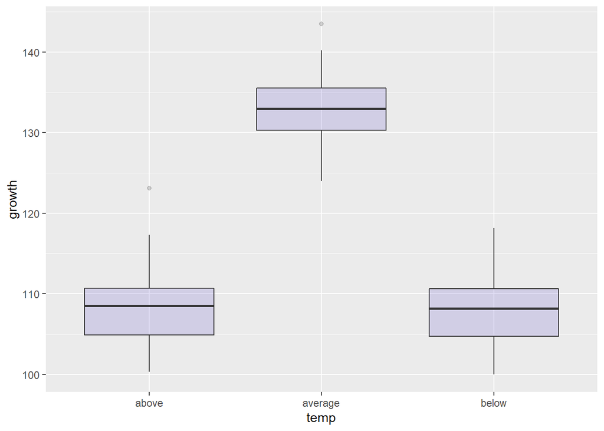

```r
# To save to a file for viewing later we use the function ggsave()
# The .tiff extension is the type of file, you can also use .jpg
# .tiff files are good for publication graphics
# ggsave("boxplot_daylength.tiff")


# Change the x variable to graph a different explanatory variable
ggplot(Species_A_Clean, aes(x=as.factor(temp_range), y=growth)) +
  geom_boxplot(fill="slateblue", alpha=0.2) +  xlab("temp")
```

```r
# ggsave("boxplot_temp.tiff")

# Here is the code to create a boxplot and save it in Base R
# Remove the # to run these 3 lines
# tiff("boxplot.tiff")
# boxplot(growth~temp_range,data=Species_A_Clean,xlab="temp_range", ylab="growth(wt")
# dev.off()
```

Notice the way we save graphics is different depending on the package we are using. Also `dev.off()` closes all graphics devices so you can start a fresh graph next time.

Create a histogram of the data using the `geom_histogram()` function. Change the `binwidth` to see what happens.

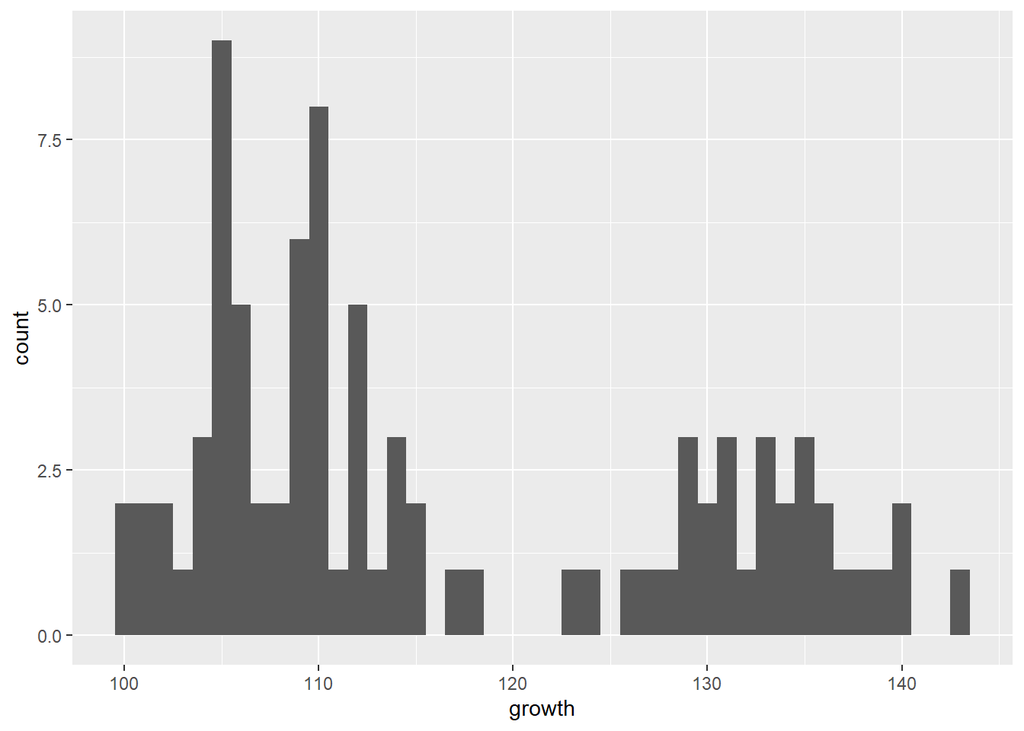

```r
ggplot(Species_A_Clean, aes(x = growth)) +
  geom_histogram(binwidth = 1)
```

```r
# You can remove the '#' in the line below if you want to save this
# ggsave("DataDistribution.tiff")

# Base R
# hist(Species_A_Clean$growth, breaks=1, col="darkgrey", main = "", xlab="growth")
```